# §1.3a — Timescales In the Universe: Scale and Light

Unit 1: Intro to the Cosmos · Astronomy

[figure not shown]

Every picture of the solar system you have seen looks something like this one: the planets crowded together, close enough to touch. **This is a BAD picture, because objects are not to scale.** With the sizes right you could not see the small planets at all. With the distances right the page would be more than a kilometer wide.

Today: shrink the solar system until the Sun is a basketball.

Solar System Montage, artist's concept. NASA/JPL

## 1 · The numbers at a glance

📏

Earth to Sun

light crosses it in 8.3 minutes

💡

The speed of light

300,000 km every second · seven and a half times around Earth

🌌

One light-year

a distance, not a time · $6.31\times10^{4}$ AU

## 2 · Scale, light and time

Click a tile.

[figure not shown]

1

Scale Model of Solar System

a basketball Sun and a long walk

[figure not shown]

2

Light years

velocity, and a ruler made of light

[figure not shown]

3

Telescopes = Time Machines

who sees what, and when

← scroll the tiles →

### Scale Model of Solar System

To build an honest picture, shrink everything by the same amount. **I shrink down the Sun to the size of a basketball. This means a 5 billion times shrinking.** The Sun's radius is 696,340 km and the basketball's is 14 cm, so every size and every distance gets divided by the same 5 billion.

**Shrink.** $\text{Scaled Size} = \dfrac{\text{actual size}}{\text{shrink}}$ and $\text{Scaled Dist.} = \dfrac{\text{actual distance}}{\text{shrink}}$, with the *same* shrink for both. Put both lengths in the same unit before you divide.

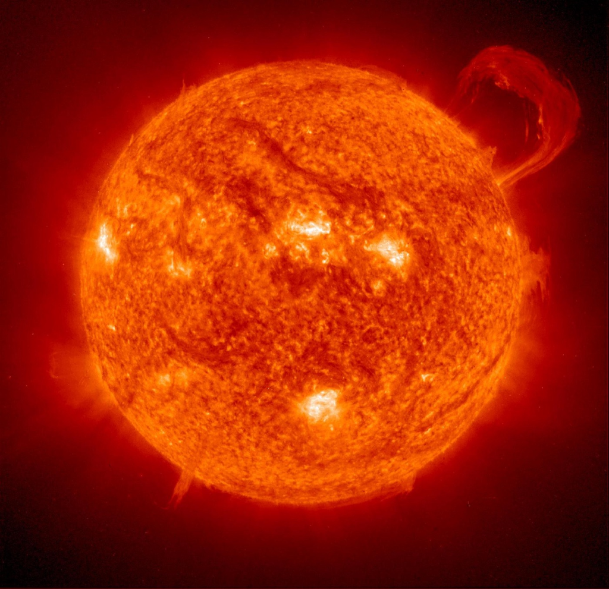

**The Sun**, radius 696,340 km. In the model this is the basketball. The loop at the edge is a prominence, a cloud of gas many Earths tall. SOHO (ESA & NASA)

[figure not shown]

**Earth, from 6 billion km.** Voyager 1 looked back in 1990 from about where Pluto orbits. The dot in the sunbeam is home. NASA/JPL-Caltech

Shrink machine: fill in the table

Model Sun:

This represents a shrinking oftimes

| Object | Size (radius in km) | Distance from the Sun | Scaled Size | Scaled Dist. |
| --- | --- | --- | --- | --- |

Type plain numbers or powers of ten (`5e9` or `5x10^9`). An answer within about 10% counts.

Now take the model outside. Put the basketball at the south end of the South Park Blocks, by PSU, and walk north toward Burnside. **Plan the walk first.** Drag each planet to where you think it lands, click it to read the spot, and write the places down. The first few planets are close enough to measure with a tape. Once you reach the first street, name the spot by its streets, for example *halfway between Columbia and Clay*.

The walk: plan it, then check it

[interactive chart not shown]

Drag a planet down onto the walk. Click any placed planet to read where it is.

speed×0.5 street guide

The class plan: where each one goes

| Object | Scaled Dist. | Where on the walk (edit it into your own words) |
| --- | --- | --- |

Street positions are approximate (about 80 m per block, counted north from SW Jackson). Check them on the walk. The walk uses whichever model Sun you picked above.

### Light years

The model works for planets. It fails for stars: at the basketball shrink the nearest star is still about 8,000 km away. **For galaxies we need to use light years (ly)!**

**The speed of light.** $c = 300{,}000\ \text{km/s} = 3\times10^{5}\ \text{km/s}$, or in terms of meters $\boxed{c = 3\times10^{8}\ \text{m/s}}$

[figure not shown]

**The Milky Way**, about 100,000 ly across. **100,000 ly is a distance.** It means how far a light wave would travel in 100,000 years going at $c$. This is a map, not a photograph: nothing we have built has ever left the galaxy. NASA/JPL-Caltech (R. Hurt)

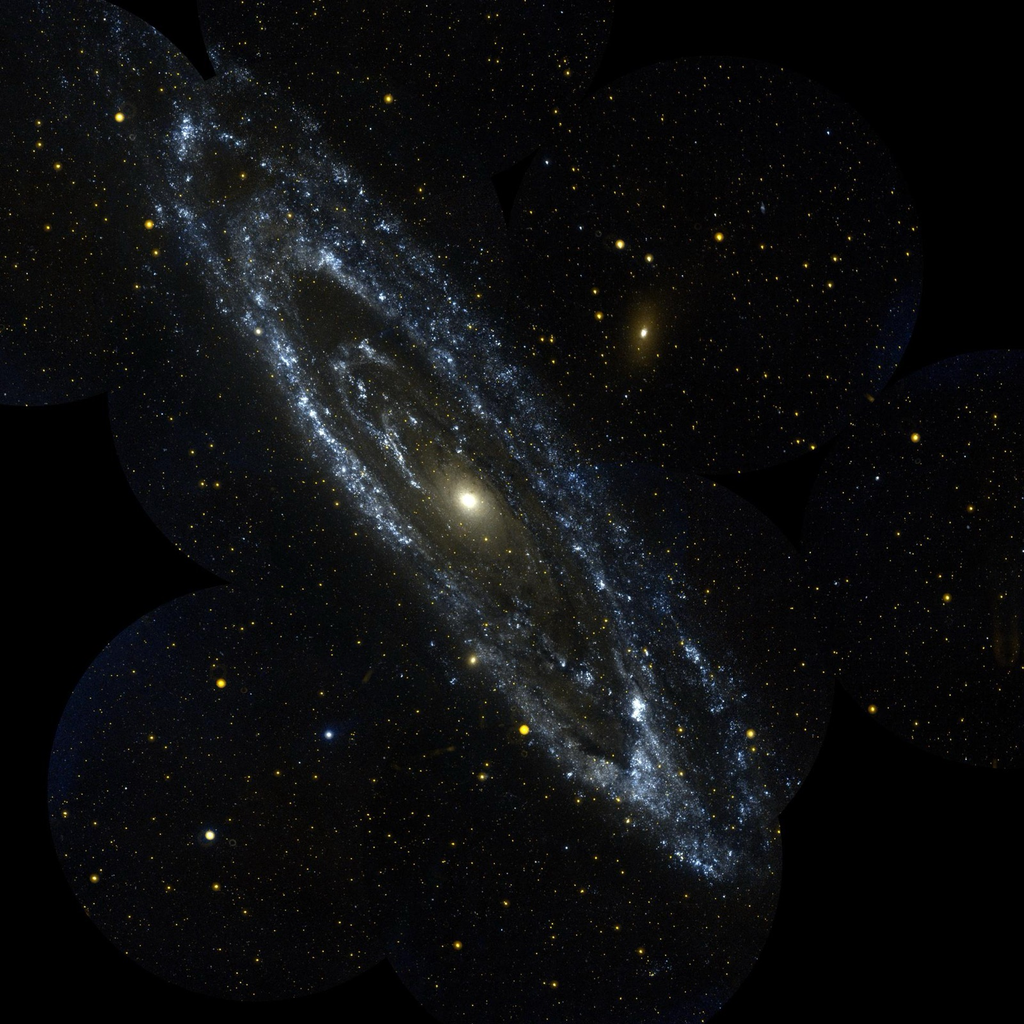

**The Andromeda Galaxy**, 2.2 Mly away: the farthest thing you can see with your own eyes. NASA/JPL-Caltech (GALEX)

**The concept of light year is linked to velocity.**

$\text{velocity} = \dfrac{\text{distance}}{\text{time}}$, or $\boxed{v = \dfrac{d}{t}}$. The same sentence solved for each thing you might want: $\quad d = v\,t \qquad t = \dfrac{d}{v}$

Ex. 1 · Cars and photons

A car moves 30 km in 2 hr. What is its velocity?

**Reveal**

$v = \dfrac{d}{t} = \dfrac{30\ \text{km}}{2\ \text{hr}} = \boxed{15\ \text{km/hr}}$

A car moves 30 km in 1 hr. What is its velocity? And in 0.5 hr?

**Reveal**

$v = \dfrac{30\ \text{km}}{1\ \text{hr}} = \boxed{30\ \text{km/hr}}$ and $v = \dfrac{30\ \text{km}}{0.5\ \text{hr}} = \boxed{60\ \text{km/hr}}$. Same distance, half the time, twice the velocity.

A photon moves 300,000 km in 1 second. What is its velocity?

**Reveal**

$v = \dfrac{300{,}000\ \text{km}}{1\ \text{s}} = \boxed{3\times10^{5}\ \text{km/s}}$. That is $c$.

How far does a photon move in 1 second, if it is moving at $c$? In 2 seconds?

**Reveal**

Solve for $d$: $d = v\,t$. In 1 s, $d = (3\times10^{5}\ \text{km/s})(1\ \text{s}) = \boxed{3\times10^{5}\ \text{km}}$. In 2 s, $\boxed{6\times10^{5}\ \text{km}}$.

How far does a photon move in 1 year, if it is moving at $c$?

**Reveal**

This one has a name. See Ex. 2.

**For light-distances**, solve for $d$ in the equation above and use $c$ for its velocity: $\boxed{d = ct}$

Ex. 2 · 1 ly

How many meters is one light-year?

**Reveal**

$$\begin{aligned} d_{ly} &= \left(3\times10^{8}\ \text{m/s}\right)\left(365\times24\times60\times60\ \text{seconds}\right)\\ &= \left(3\times10^{8}\ \text{m/s}\right)\left(3.15\times10^{7}\ \text{s}\right)\\ &= \boxed{9.46\times10^{15}\ \text{meters}} \end{aligned}$$

How long does the light take? Guess the unit, then send it

My guess:

[interactive chart not shown]

### Telescopes = Time Machines

Light takes time to arrive, so every look outward is a look back. You see the Sun as it was 8.3 minutes ago and the Andromeda Galaxy as it was 2.2 million years ago. The light-year makes the arithmetic free: **something 50 ly away is seen as it was 50 years ago.**

[figure not shown]

**Hubble's deepest view.** Nearly every smudge is a galaxy. The faintest are seen as they were more than 13 billion years ago, a few hundred million years after the beginning. NASA, ESA, and the HUDF09/XDF teams

It works in both directions. **Due to light travel time, alien astronomers see Earth at different times of the past.** For the location of each alien observer, match what they see happening on Earth.

Group discussion: who sees what?

Click an observer, then click what they see. ly = light-years, Mly = million, Gly = billion.

[figure not shown]

**The oldest light there is.** The cosmic microwave background (CMB) set out 13.8 billion years ago, before there were any stars. Every direction you look ends here. ESA and the Planck Collaboration

## 3 · Lookback time in pictures

Swipe through the pictures, or use the arrows. For each one decide **how long ago the light left**, pick a unit, then tap the picture to reveal.

**How to calculate the time.** Start from $v = \dfrac{d}{t}$. Solve for the time, and use $c$ for the velocity: $\boxed{t = \dfrac{d}{c}}$

**Ex.** The Sun is $1.5\times10^{11}$ m away. How long ago did its light leave?

$$t = \frac{d}{c} = \frac{1.5\times10^{11}\ \text{m}}{3\times10^{8}\ \text{m/s}} = 500\ \text{s} \qquad 500\ \text{s}\times\frac{1\ \text{min}}{60\ \text{s}} = \boxed{8.3\ \text{minutes}}$$

If the distance is already in light-years there is nothing to calculate: 4.24 ly away means the light left 4.24 years ago.

[figure not shown]

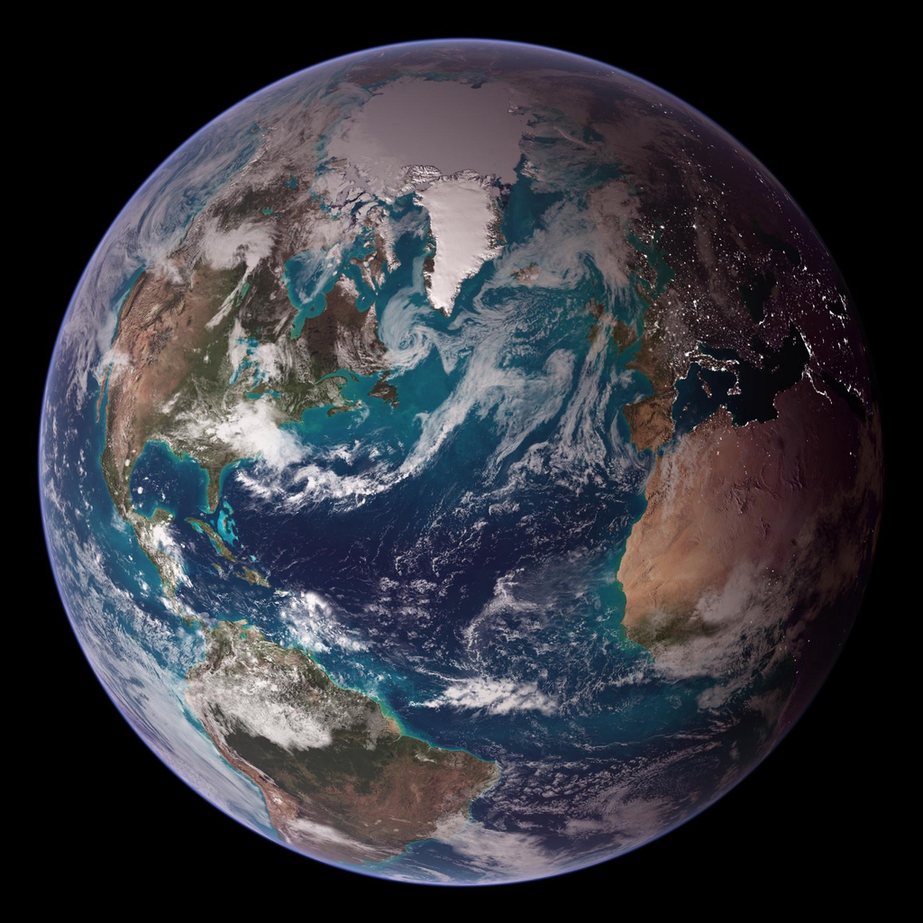

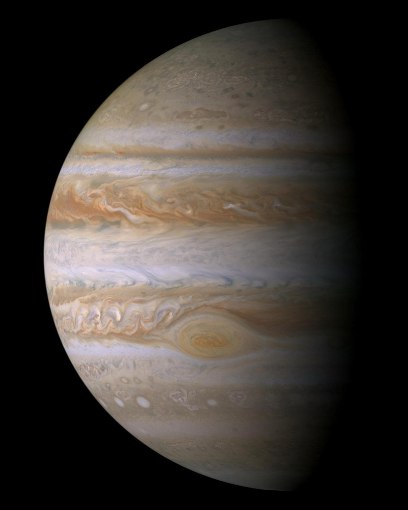

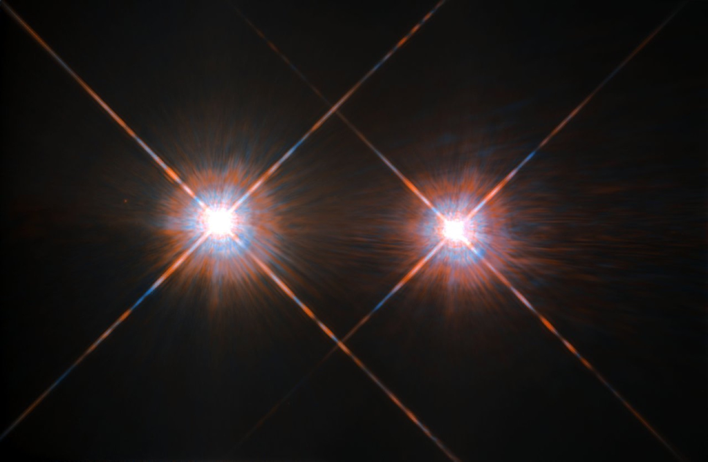

[figure not shown]

Keyboard: ← → to move, space to reveal (click the picture first). On a phone, swipe left or right.

**Sources and further reading**

Want to dig deeper? Each title links straight to the original.

**Scale model of the solar system**

- [Our solar system](https://science.nasa.gov/solar-system/) (NASA): a tour of the Sun, the planets and what lies beyond them.
- [Voyage: a scale model on the National Mall](https://science.nasa.gov/resource/the-voyage-scale-model-solar-system/) (NASA): a real walk-through model of the solar system, shrunk ten billion times.
- [Pale Blue Dot](https://images.nasa.gov/details/PIA23645) (NASA/JPL-Caltech): Voyager 1's picture of Earth from 6 billion km.

**Light-years**

- [What is a light-year?](https://science.nasa.gov/exoplanets/what-is-a-light-year/) (NASA): a distance, not a time, and how far it really is.
- [How far is a light-year?](https://spaceplace.nasa.gov/light-year/en/) (NASA Space Place): a short, friendly explainer with pictures.

**Telescopes are time machines**

- [Hubble's deep fields](https://science.nasa.gov/mission/hubble/science/universe-uncovered/hubble-deep-fields/) (NASA): how staring at one dark patch of sky for days revealed thousands of galaxies.
- [The Hubble eXtreme Deep Field](https://esahubble.org/images/heic1214a/) (ESA/Hubble): the full-size version of the picture on this page.
- [Webb's first deep field](https://science.nasa.gov/missions/webb/nasas-webb-delivers-deepest-infrared-image-of-universe-yet/) (NASA): the James Webb Space Telescope's first look at very distant galaxies, 2022.

The page's numbers come from the class notes; to check a planet's size, distance or year, use NASA's Planetary Fact Sheet. All pictures are from the NASA Image and Video Library.

**Image credits**

All pictures are from the NASA Image and Video Library. Solar System Montage (PIA10969), NASA/JPL. Handle-shaped Prominence (PIA03149), SOHO (ESA & NASA). Pale Blue Dot Revisited (PIA23645), NASA/JPL-Caltech. Blue Marble 2007 West, NASA/GSFC. Portrait of Pluto and Charon (PIA19717), NASA/Johns Hopkins University Applied Physics Laboratory/Southwest Research Institute. Cassini Jupiter Portrait (PIA04866), NASA/JPL/Space Science Institute. Alpha Centauri A and B, ESA/Hubble and NASA. Our Milky Way Gets a Makeover, artist's concept (PIA10748), NASA/JPL-Caltech (R. Hurt). Andromeda Galaxy (PIA04921), NASA/JPL/California Institute of Technology (GALEX). Hubble eXtreme Deep Field, NASA, ESA, and the HUDF09/XDF teams. Best Map Ever of the Universe (PIA16873), ESA and the Planck Collaboration.